# Quality of Weight lifting exercises

Cherie

18/05/2015

# Overview

In this project, the goal is to use data from accelerometers on the belt, forearm, arm, and dumbell of 6 participants and predict whether they performed barbell lifts correctly and incorrectly in 5 different ways (classe).

The data link is https://d396qusza40orc.cloudfront.net/predmachlearn/pml-training.csv

This write up document describes the analysis.

# Getting and cleaning data

The dataset was split in a training (60%) and testing (40%) set. Columns with a significant number (96%) of Missing values (NA) were removed and columns with significant Near-zero-values. Additionally, the X column was identified as a confounding variable and removed. The classes of the training and test sets were unified.

```r
dim(training); dim(testing)
```

```
## [1] 11776   160
```

```
## [1] 7846  160
```

## Exploratory Data Analysis

The remaining data (58 variables) was reviewed with functions dim, str, summary. The distribution of the outcome variable was reviewed and featurePlots of the 58 variables were run.

```
##  [1] "caret"     "ggplot2"   "lattice"   "stats"     "graphics"
##  [6] "grDevices" "utils"     "datasets"  "methods"   "base"
```

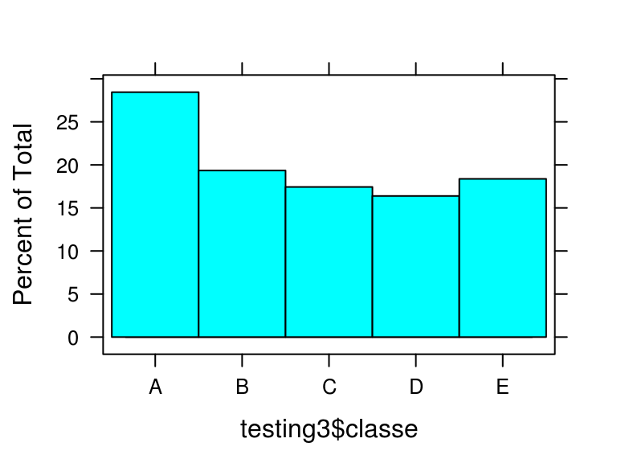

## Variable Importance and model selection

Relative importance is assessed using varImp function before and after NZV were removed. NZV proved to have little impact.

```r
RocImp_inclNZV <- filterVarImp(x=training2[, -ncol(training2)], y=training2$classe)
RocImp_exclNZV <- filterVarImp(x=training3[, -ncol(training3)], y=training3$classe)
summary(RocImp_exclNZV)
```

```
##        A                B                C                D
##  Min.   :0.5110   Min.   :0.5111   Min.   :0.5060   Min.   :0.5116
##  1st Qu.:0.5335   1st Qu.:0.5434   1st Qu.:0.5434   1st Qu.:0.5463
##  Median :0.5973   Median :0.5786   Median :0.5804   Median :0.5759
##  Mean   :0.6027   Mean   :0.5921   Mean   :0.5953   Mean   :0.5995
##  3rd Qu.:0.6549   3rd Qu.:0.6359   3rd Qu.:0.6390   3rd Qu.:0.6390
##  Max.   :0.8011   Max.   :0.7216   Max.   :0.7583   Max.   :0.8011
##        E
##  Min.   :0.4995
##  1st Qu.:0.5391
##  Median :0.5810
##  Mean   :0.5905
##  3rd Qu.:0.6409
##  Max.   :0.7028
```

Three model were selected (with the accuracy statistic from the confusionMatrix alongside): 1. with all 58 remaining variables (99.99% accuracy) 2. included variables with importance > 70% (65% accuracy) 3. variables with importance > 60% (92.7% accuracy)

The train function is used to evaluate, using 5 fold resampling, the effect of model tuning paramters on performance, choose the “optimal” model across these parameters and estimate model performance from a training set. A gradient boosting machine (GBM) model was used with three main tuning parameters: - number of iterations set to (1:30)*50 - complexity of the tree set through the interaction.depth parameter at (2, 5, 13) - learning rate: how quickly the algorithm adapts, called shrikage (set at 0.1) - the minimum number of training set samples in a node to commence splitting (n. minobsinnode=10)

The confusionMatrix below shows the results compared to the actual classe in the training set.

```
## Confusion Matrix and Statistics
##
##           Reference
## Prediction    A    B    C    D    E
##          A 3348    0    0    0    0
##          B    0 2278    1    0    0
##          C    0    0 2054    0    0
##          D    0    0    0 1930    0
##          E    0    0    0    0 2165
##
## Overall Statistics
##
##                Accuracy : 0.9999
##                  95% CI : (0.9995, 1)
##     No Information Rate : 0.2843
##     P-Value [Acc > NIR] : < 2.2e-16
##
##                   Kappa : 0.9999
##  Mcnemar's Test P-Value : NA
##
## Statistics by Class:
##
##                      Class: A Class: B Class: C Class: D Class: E
## Sensitivity            1.0000   1.0000   0.9995   1.0000   1.0000
## Specificity            1.0000   0.9999   1.0000   1.0000   1.0000
## Pos Pred Value         1.0000   0.9996   1.0000   1.0000   1.0000
## Neg Pred Value         1.0000   1.0000   0.9999   1.0000   1.0000
## Prevalence             0.2843   0.1934   0.1745   0.1639   0.1838
## Detection Rate         0.2843   0.1934   0.1744   0.1639   0.1838
## Detection Prevalence   0.2843   0.1935   0.1744   0.1639   0.1838
## Balanced Accuracy      1.0000   0.9999   0.9998   1.0000   1.0000
```

```
## Confusion Matrix and Statistics
##
##           Reference
## Prediction    A    B    C    D    E
##          A 2209   12   11    0    0
##          B   25 1456   34    3    0
##          C    0   29 1332    7    0
##          D    0    0   56 1222    8
##          E    0    0    2    6 1434
##
## Overall Statistics
##
##                Accuracy : 0.9754
##                  95% CI : (0.9717, 0.9787)
##     No Information Rate : 0.2847
##     P-Value [Acc > NIR] : < 2.2e-16
##
##                   Kappa : 0.9689
##  Mcnemar's Test P-Value : NA
##
## Statistics by Class:
##
##                      Class: A Class: B Class: C Class: D Class: E
## Sensitivity            0.9888   0.9726   0.9282   0.9871   0.9945
## Specificity            0.9959   0.9902   0.9944   0.9903   0.9988
## Pos Pred Value         0.9897   0.9592   0.9737   0.9502   0.9945
## Neg Pred Value         0.9955   0.9935   0.9841   0.9976   0.9988
## Prevalence             0.2847   0.1908   0.1829   0.1578   0.1838
## Detection Rate         0.2815   0.1856   0.1698   0.1557   0.1828
## Detection Prevalence   0.2845   0.1935   0.1744   0.1639   0.1838
## Balanced Accuracy      0.9924   0.9814   0.9613   0.9887   0.9966
```

A plots below examine the relationship between the estimates of performance and the tuning parameters.

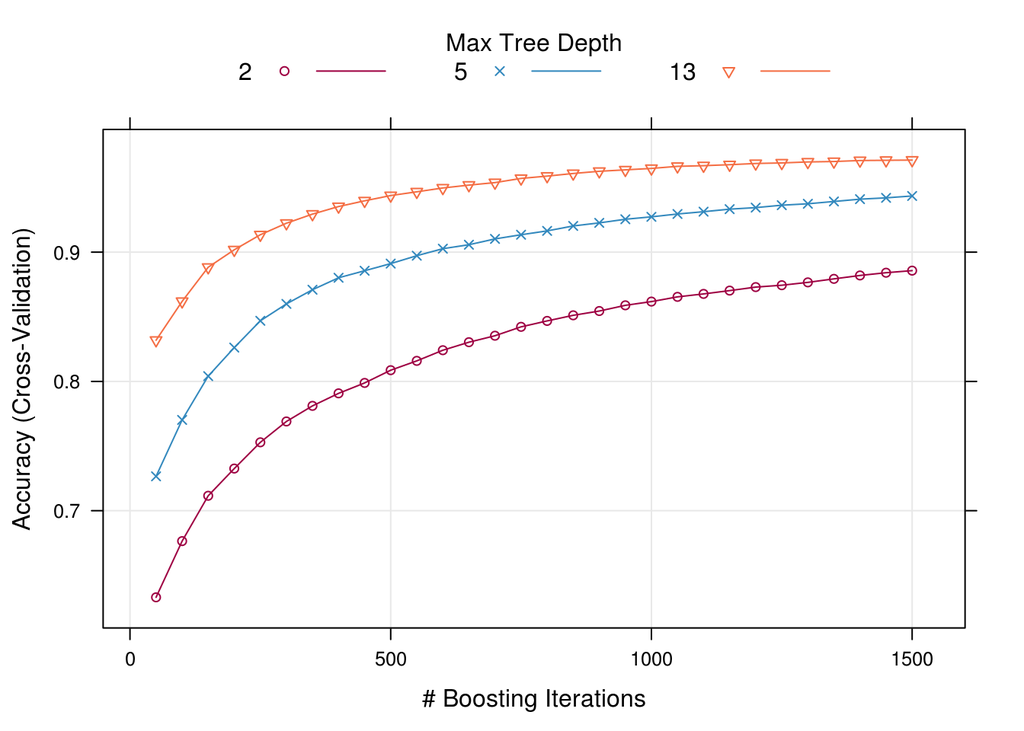

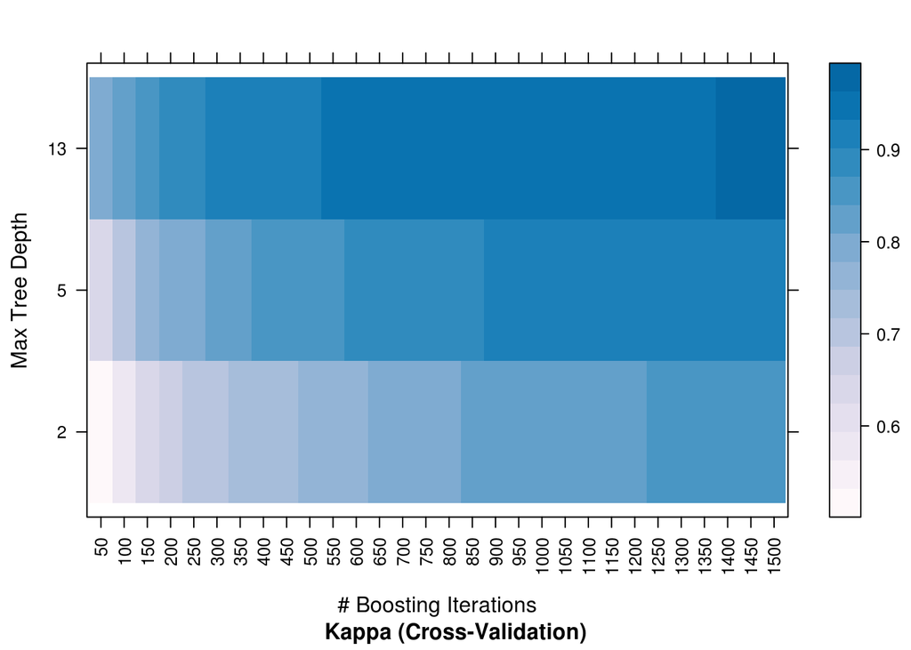

The model was used to predict the classe of the 20 test cases which were submitted to Coursera.

```
##  [1] B A C A A E D B A A B C B A E E A B B B
## Levels: A B C D E
```

This resulted in 19 correct answers and 1 error. Based on these results degree of impurity is measured as follows: Misclassification: 0.05; Gini: 0.095; and No Information Rate: 0.286397.

20 Individual files were created using the code below which was provided. pml_write_files = function(x){ + n = length(x) + for(i in 1:n){ + filename = paste0(“problem_id_”,i,“.txt”) + write.table(x[i],file=filename,quote=FALSE,row.names=FALSE,col.names=FALSE) + } + } pml_write_files(answers)